# Design & Analysis workshop

Priscila López-Beltrán Forcada

Spring 2021

In this session, we will learn how to create models in which the dependent variable is categorical.

There are several ways in which the relationship between categorical variables can be analyzed. The most important concept to keep in mind is that we won’t be able to compute basic operations such as the mean. Instead, we will consider frequencies or *counts* of instances in each level of the variables.

See the following **contingency table**

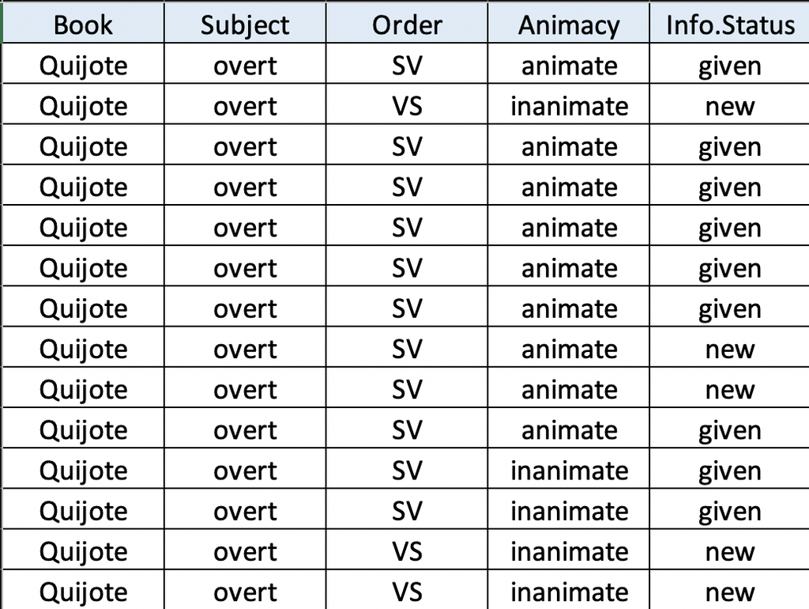

We have 5 categorical variables here:

- **Book:** Quijote
- **Subject:** overt
- **Order:** SV / VS
- **Animacy:** animate / inanimate
- **Information Status:** given / new

In this corpus data set, we are interested in knowing whether overt pre-verbal subjects (SV) have a tendency to be animate and to represent given information, as shown by other studies.

First, which are the DV and IV here?

**Answer**

Correct:

- DV: Order (SV/VS)
- IV: Animacy (animate/inanimate) and Info.Status (given/new)

Second, we will examine each variable separately. Let’s visualize them, what are the tends we observe?

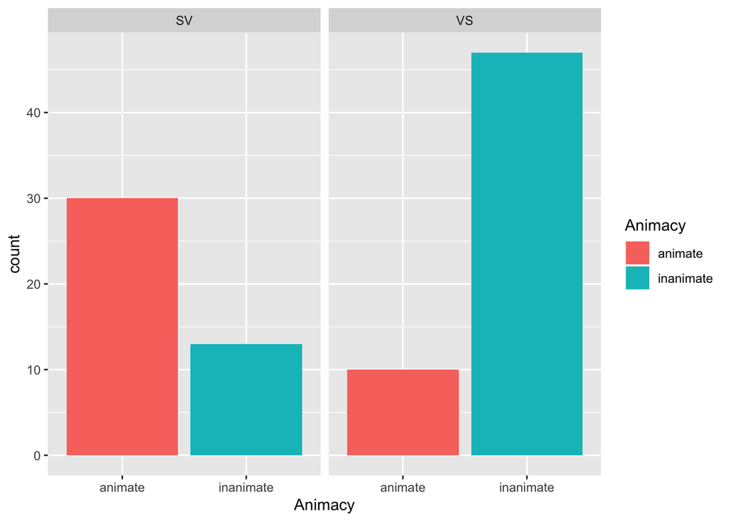

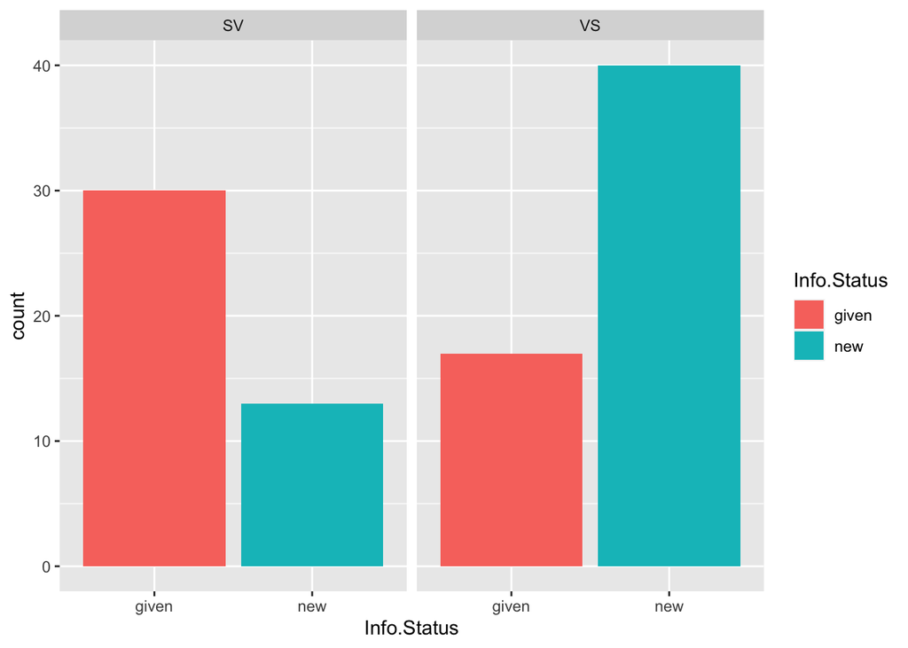

**Answer**

Correct:

- SV tends to be *animate* while VS tends to be *inanimate*
- SV tends to be *given* information while VS tends to be *new* information

Now, the first an simplest test that we can perform with categorical variables is the **chi-square test**, which analyzes the relationship between **two** categorical variables. To put it simply, this test compares the frequencies observed in certain categories to the frequencies we might expect to get in those categories by chance. Thus, what we’ll be testing is if the rows and columns in a contingency table are **significantly associated**.

**Assumptions**

**In statistical analysis, all parametric tests assume some certain characteristic about the data, also known as assumptions. Violation of these assumptions changes the conclusion of the research and interpretation of the results.**

In the case of Chi-square:

- The data points must be independent; cannot be used with repeated measures.
- The frequencies in each cell must be greater than 5; we need a large sample.

**How to conduct a Chi-square test**

First, we will transform all variables into factors using the `as.factor()` function.

Then, we create a contingency table with the two factors we want to test significance for. We will use the `CrossTable()` function in the package `gmodels`

Animacy:

```r
tbl1 <- table(cdata$Order, cdata$Animacy)
CrossTable(tbl1, fisher= T, chisq = T, expected = T, sresid= T)
```

```
##
##
##    Cell Contents
## |-------------------------|
## |                       N |
## |              Expected N |
## | Chi-square contribution |
## |           N / Row Total |
## |           N / Col Total |
## |         N / Table Total |
## |-------------------------|
##
##
## Total Observations in Table:  100
##
##
##              |   animate | inanimate | Row Total |
## -------------|-----------|-----------|-----------|
##           SV |        30 |        13 |        43 |
##              |    17.200 |    25.800 |           |
##              |     9.526 |     6.350 |           |
##              |     0.698 |     0.302 |     0.430 |
##              |     0.750 |     0.217 |           |
##              |     0.300 |     0.130 |           |
## -------------|-----------|-----------|-----------|
##           VS |        10 |        47 |        57 |
##              |    22.800 |    34.200 |           |
##              |     7.186 |     4.791 |           |
##              |     0.175 |     0.825 |     0.570 |
##              |     0.250 |     0.783 |           |
##              |     0.100 |     0.470 |           |
## -------------|-----------|-----------|-----------|
## Column Total |        40 |        60 |       100 |
##              |     0.400 |     0.600 |           |
## -------------|-----------|-----------|-----------|
##
##
## Statistics for All Table Factors
##
##
```

[output cut: 12 more lines]

```
##
## Alternative hypothesis: true odds ratio is not equal to 1
## p =  1.459459e-07
## 95% confidence interval:  3.863271 31.19104
##
## Alternative hypothesis: true odds ratio is less than 1
## p =  1
## 95% confidence interval:  0 26.49258
##
## Alternative hypothesis: true odds ratio is greater than 1
## p =  1.256726e-07
## 95% confidence interval:  4.434958 Inf
##
##
##
```

Information Status:

```r
tbl2 <- table(cdata$Order, cdata$Info.Status)
CrossTable(tbl2, fisher= T, chisq = T, expected = T, sresid= T)
```

```
##
##
##    Cell Contents
## |-------------------------|
## |                       N |
## |              Expected N |
## | Chi-square contribution |
## |           N / Row Total |
## |           N / Col Total |
## |         N / Table Total |
## |-------------------------|
##
##
## Total Observations in Table:  100
##
##
##              |     given |       new | Row Total |
## -------------|-----------|-----------|-----------|
##           SV |        30 |        13 |        43 |
##              |    20.210 |    22.790 |           |
##              |     4.742 |     4.206 |           |
##              |     0.698 |     0.302 |     0.430 |
##              |     0.638 |     0.245 |           |
##              |     0.300 |     0.130 |           |
## -------------|-----------|-----------|-----------|
##           VS |        17 |        40 |        57 |
##              |    26.790 |    30.210 |           |
##              |     3.578 |     3.173 |           |
##              |     0.298 |     0.702 |     0.570 |
##              |     0.362 |     0.755 |           |
##              |     0.170 |     0.400 |           |
## -------------|-----------|-----------|-----------|
## Column Total |        47 |        53 |       100 |
##              |     0.470 |     0.530 |           |
## -------------|-----------|-----------|-----------|
##
##
## Statistics for All Table Factors
##
##
```

[output cut: 12 more lines]

```
##
## Alternative hypothesis: true odds ratio is not equal to 1
## p =  0.0001050622
## 95% confidence interval:  2.115012 14.154
##
## Alternative hypothesis: true odds ratio is less than 1
## p =  0.9999878
## 95% confidence interval:  0 12.21368
##
## Alternative hypothesis: true odds ratio is greater than 1
## p =  7.272643e-05
## 95% confidence interval:  2.40885 Inf
##
##
##
```

Let’s break down these outputs:

Next we have the actual Chi-square results. The tests’ output indicates that the row and column variables are statistically significantly associated for Animacy and Information Status.Thus, the tests confirm that what we saw in the bar plots we graphed is statistically significant.

Finally, the output shows the sample estimate odds ratio, indicating the effects size. Effect size is a quantitative measure of *the magnitude of the experimental effect*. The larger the effect size the stronger the relationship between two variables. You can look at the effect size when comparing any *two groups* to see how substantially different they are. Odds ratios measure how many times bigger the odds of one outcome is for one value of an IV, compared to another value.

We see that the odds ratio is highly significant and not equal to 1, which is what we’d want because this is the point at which the direction of the effect changes. In this case, the odds of SV are greater when the subject is animate or given.

**Binary Logistic Regression**

So far our focus has been on describing interactions or associations between two categorical variables mostly via single summary statistics and with significance testing, as well as by looking at the variables separately. We will now focus on a special class of models known as the *binary logistic regression*.

Binary Logistic Regression is a special type of regression where a *binary response variable* is related to a set of explanatory variables, which can be discrete and/or continuous.

Linear regression is not capable of predicting probability. If you use linear regression to model a binary response variable, for example, the resulting model may not restrict the predicted Y values within 0 and 1, as shown below. Here’s where logistic regression comes into play, where you get a probability score that reflects the probability of the occurrence at the event.

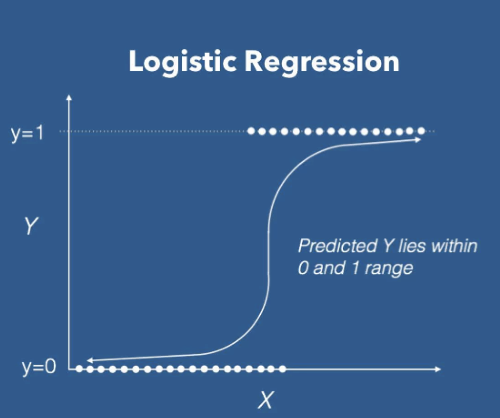

In logistic regression, the *Probability or Odds* of the response taking a particular value is modeled based on combination of values taken by the predictors. More formally, the equation models *the logit-transformed probability as a linear relationship with the predictor variables.* In our case, we will use logistic regression to model the probability that subject-verb order belongs to a particular category, SV or VS [*Pr(SV-order = SV/VS)*].

**Assumptions**

- the dependent variable has a *binomial* distribution. The binomial distribution is a probability distribution that summarizes the likelihood that a value will take one of two independent values under a given set of parameters or assumptions.
- the errors are normally distributed and independent.
- does not assume a linear relationship between DV and IVs.

**Visualization**

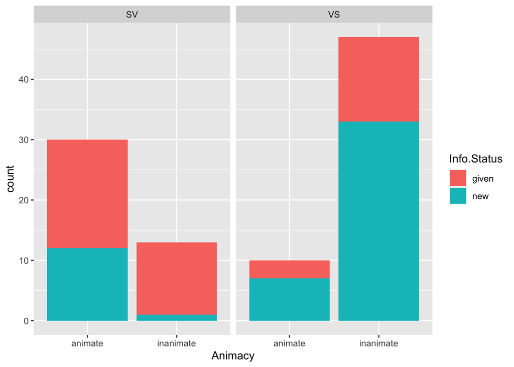

Let’s create our model:

```r
 model1 <-  glm(Order ~ Animacy + Info.Status, family= binomial, data=cdata)
 summary(model1)
```

```
##
## Call:
## glm(formula = Order ~ Animacy + Info.Status, family = binomial,
##     data = cdata)
##
## Deviance Residuals:
##     Min       1Q   Median       3Q      Max
## -2.3097  -0.5716   0.3794   0.3794   2.2585
##
## Coefficients:
##                  Estimate Std. Error z value Pr(>|z|)
## (Intercept)       -2.4691     0.6064  -4.071 4.67e-05 ***
## Animacyinanimate   2.8364     0.6071   4.672 2.98e-06 ***
## Info.Statusnew     2.2281     0.6008   3.709 0.000208 ***
## ---
## Signif. codes:  0 '***' 0.001 '**' 0.01 '*' 0.05 '.' 0.1 ' ' 1
##
## (Dispersion parameter for binomial family taken to be 1)
##
##     Null deviance: 136.663  on 99  degrees of freedom
## Residual deviance:  89.903  on 97  degrees of freedom
## AIC: 95.903
##
## Number of Fisher Scoring iterations: 5
```

Before we read this output, there are three concepts we need to understand:

- **Probability:** ranges from 0-1;for example, a event might have a .8 success probability.
- **Odds:** range from 0 and positive infinity; defined, for example, as the ratio of the probability of success over the probability of failure, then 8/.2 = 4. That is to say that the odds of success are 4 to 1.
- **Log-odds:** the transformation from odds to log of odds is the log transformation, and it ranges from negative infinity to positive infinity. We transform probability into log-odds because it is usually difficult to model a variable which has restricted range.

#### **1. Deviance**

Deviance is a measure of *goodness of fit of a generalized linear model*, higher numbers indicate worse fit.

The null deviance shows how well the response variable is predicted by a model that includes only the intercept (grand mean) and the residual deviance includes all predictors.

#### **2. Fisher’s Scoring Iterations**

For our model, we see that Fisher’s Scoring Algorithm needed 5 iterations to perform the fit.

#### **3. Coefficients**

**A. Estimates**: These are the values for the logistic regression equation for predicting the dependent variable from the independent variable. They are in *log-odds units.*

**B. Std. Err**: These are the standard errors associated with the coefficients. The standard error is used for testing whether the parameter is significantly different from 0.

**C. z and P>|z|**: These columns provide the z-value and 2-tailed p-value used in testing the null hypothesis that the coefficient (parameter) is 0.

As a final step let’s interpret the Estimates:

The Estimates ina logistic regression model tell you about the relationship between the independent variables and the dependent variable, where the dependent variable is on the logit scale. These estimates tell the amount of increase in the predicted log odds of *Order* that would be predicted by a 1 unit increase in the predictor, holding all other predictors constant

Because these coefficients are in log-odds units, they are often difficult to interpret, so they are often converted into *odds ratios* or back into *probabilities.* Here, we will do he latter.

**1. Dependent variable:** when we used `CrossTable` to perform Chi-Square tests, we were provided a distribution table (similar to *Goldvarb*) and saw that thre freuency of VS (57) was higher than SV (43). We need to take this into account when interpreting our estimates.

**3. Predictors** For Animacy-Inanimate and Info.Status-New, we see that *both* of them are significantly positive, indicating a positive likelihood of VS being inanimate and new.

- Animacy-Inanimate: *-2.469 + 2.863 = 0.367 -> p= 0.59*
- Info.Status-New: *-2.469 + 2.228 = -0.241 -> p= 0.43*

In all, these numbers together with our distribution tables and graphs paint a clear picture where post-verbal subjects have a tendency to be inanimate and new, whereas pre-verbal subjects tend to be animate and given.

### Resources

- This corresponds to Andy Fields’ book Chapters 13 & 18; see also chapters 1.5.1.2 and 6.5.7.
- This corresponds to Levshina’s book Chapter 9
- Chi-square
  - http://www.sthda.com/english/wiki/chi-square-test-of-independence-in-r
- Assumptions
  - https://www.statisticssolutions.com/common-assumptions-in-statistics/#:~:text=Usually%20in%20inferential%20statistics%2C%20certain,be%20assessed%20prior%20to%20analysis.&text=A%20few%20of%20the%20most,the%20analysis%20are%20normally%20distributed.
- Effect size
- https://www.theanalysisfactor.com/effect-size-statistics-logistic-regression/#:~:text=Odds%20ratios%20measure%20how%20many,IV%2C%20compared%20to%20another%20value.&text=That%20odds%20ratio%20is%20an,that%20the%20plant%20is%20present.
- https://cran.r-project.org/web/packages/effectsize/effectsize.pdf
- Regression
  - https://www.datacamp.com/community/tutorials/logistic-regression-R
  - https://stats.idre.ucla.edu/other/mult-pkg/faq/general/faq-how-do-i-interpret-odds-ratios-in-logistic-regression/
  - https://stats.idre.ucla.edu/other/mult-pkg/faq/general/faq-how-do-i-interpret-odds-ratios-in-logistic-regression/
  - https://www.theanalysisfactor.com/r-glm-model-fit/
  - https://towardsdatascience.com/implementing-binary-logistic-regression-in-r-7d802a9d98fe